# ANOVA à un facteur

2eme-FA-EMS - BUT SD - E. Anakok

```r
library(tidyverse)
library(extrafont)
require(ggsci)
library(ggpubr)
library(knitr)
library(ggfortify)
library(ggrepel)
library(corrplot)
```

# 1 Introduction

## 1.1 Ce qu’il faut retenir de ce cours

**TipEncodage 1 parmi p**

$$X = \begin{bmatrix} \text{Groupe 1} \\ \text{Groupe 2} \\ \text{Groupe 1} \\ \text{Groupe 3} \\ \text{Groupe 2} \\ \text{Groupe 3} \end{bmatrix} \quad \text{en} \quad X^{(1)} = \left[\begin{array}{ccc} \text{Groupe 1} & \text{Groupe 2} & \text{Groupe 3} \\ 1 & 0 & 0 \\ 0 & 1 & 0 \\ 1 & 0 & 0 \\ 0 & 0 & 1 \\ 0 & 1 & 0 \\ 0 & 0 & 1 \end{array}\right]$$

Problème : Le modèle ainsi défini n’est pas identifiable.

**NoteDéfinition : ANOVA à un facteur sans intercept**

$$Y = X^{(1)}\theta + E$$

- $Y = [Y_1,\dots,Y_n]^t$ les v.a. à expliquer.
- $X^{(1)}$ est la matrice encodée du facteur sans l’intercept.
- $\theta = [\mu_1,\dots,\mu_p]^t$.
- $E \sim \mathcal{N}(0,\sigma^2 I_n)$.

**NoteDéfinition : ANOVA à un facteur avec groupe de référence**

$$Y = X^{(1)}\theta + E$$

- $Y = [Y_1,\dots,Y_n]^t$ les v.a. à expliquer.
- $X^{(1)}$ est la matrice encodée du facteur sans le groupe 1.
- $\theta = [\beta,\alpha_2,\dots,\alpha_p]^t$.
- $E \sim \mathcal{N}(0,\sigma^2 I_n)$.

## 1.2 Introduction

**WarningObjectifs**

- Expliquer une variable continue en fonction d’une variable catégorielle (appelée facteur).
- Généralisation du test d’égalité de deux espérances (vu en cours sur les tests) à $p$ espérances, si le facteur a $p$ modalités

**NoteDonnées**

- Les valeurs (continues) $y_i$ pour $1\leq i \leq n$
- Une classe pour chaque individu $i$

## 1.3 Exemple

**WarningObjectif**

Étude de la prise de poids d’individus en fonction de leurs régime

**NoteDonnées**

Pour $n= 76$ individus on a :

- Une variable réponse à expliquer :
  - Leur prise de poids (mesurée en kg)
- Un facteur explicatif à $p= 3$ niveau (modalités):
  - Régime 1
  - Régime 2
  - Régime 3

## 1.4 Les données

```r
diet <- read.table(file = "Diet.txt", header = TRUE, sep =";" )
diet$Diet <- as.factor(diet$Diet)
kable(head(diet))
```

| Diet | Diff_poid |
| --- | --- |
| 1 | 1.5 |
| 3 | 4.5 |
| 3 | 3.5 |
| 2 | 2.0 |
| 1 | 1.1 |
| 1 | 3.5 |

## 1.5 Étude univariées des données

```r
summary(diet$Diff_poid)
```

```
   Min. 1st Qu.  Median    Mean 3rd Qu.    Max.
 -2.100   2.300   3.700   3.946   5.650   9.200
```

Les individus perde jusqu’à 2,1 kg et gagne jusqu’à 9,2 kg.

```r
table(diet$Diet)
```

```
 1  2  3
24 25 27
```

24 individus ont fait le régime 1, 25 ont fait le régime 2, et 27 ont fait le régime 3

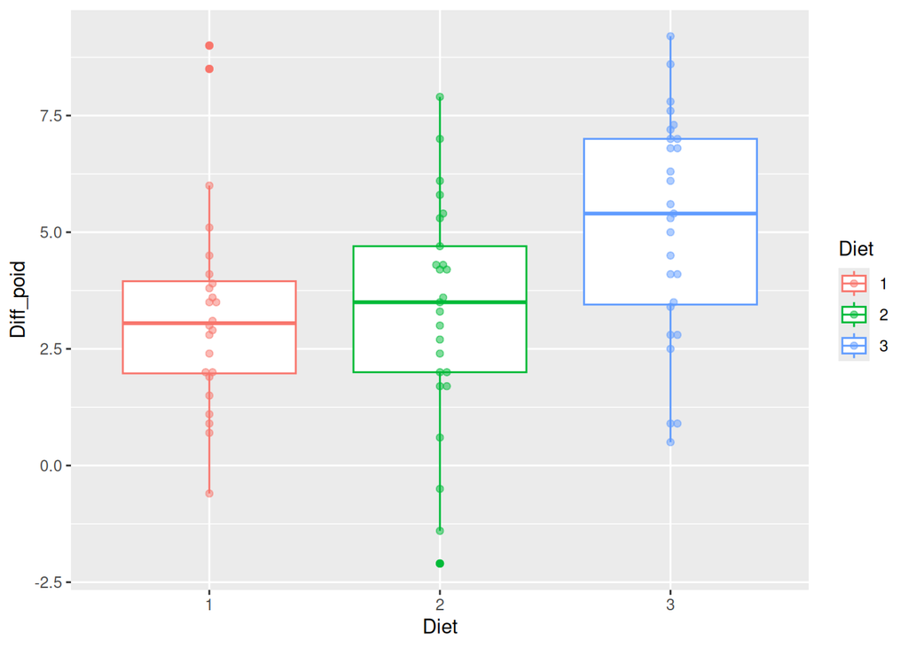

```r
library(ggbeeswarm)
ggplot(diet, aes(x= Diet, y = Diff_poid, color = Diet))+
  geom_boxplot()+
  geom_beeswarm(alpha = 0.5)
```

## 1.6 Exemple

Étude de l’effet du régile sur la variable *différence de poids* (mesuré en kg).

- Une variable réponse continue : “la prise” de poids
- Un facteur explicatif à $p=3$ niveaux (modalités) codé en
  - Régime 1
  - Régime 2
  - Régime 3

Comment analyser ces données ?

- On va calculer une estimation moyenne de *prise de poids* par régime.

## 1.7 Écriture du modèle

**NoteDéfinition**

Pour $1\leq i \leq n$ et $1\leq j \leq p$

- $y_{i,j}$ l’observation de la variable réponse du $i$-ème individu qui a la modalité $j$
- On suppose que $y_{i,j}$ est la réalisation d’une variable aléatoire $Y_{i,j}$ telle que

$$Y_{i,j} \sim \mathcal{N}(\mu_j,\sigma^2)$$
où $Y_{i,j}$ est la variable aléatoire liée à l’individu $i$ de la modalité $j$, les $Y_{i,j}$ sont indépendants.

**CautionRemarques : Nombre de paramètres**

- $p$ paramètres d’espérance (1 par modalité)
- 1 paramètre de variance

## 1.8 Trouver les paramètres ($\mu_j$ et $\sigma^2$)

**NoteCe que l’on sait faire**

Trouver les paramètres d’espérance $\theta$ tel que

$$Y = X\theta + E,\quad E \sim \mathcal{N}(0,\sigma^2 I_n)$$

**WarningProblème**

- Pour le modèle linéaire, $X$ doit être numérique (quantitatif).
- Ici, $X$ est une catégorie (qualitatif).

## 1.9 Encodage *one-hot* ou encodage 1 parmi $p$

**TipIdée**

Transformer la variable qualitative à $p$ modalité $\Longrightarrow$ $p$ variables 0/1

**TipExemple**

$$R = \begin{bmatrix} \text{Régime 1} \\ \text{Régime 2} \\ \text{Régime 1} \\ \text{Régime 3} \\ \text{Régime 2} \\ \text{Régime 3} \end{bmatrix} \quad \text{en} \quad X^{(1)} = \left[\begin{array}{ccc} \text{Régime 1} & \text{Régime 2} & \text{Régime 3} \\ 1 & 0 & 0 \\ 0 & 1 & 0 \\ 1 & 0 & 0 \\ 0 & 0 & 1 \\ 0 & 1 & 0 \\ 0 & 0 & 1 \end{array}\right]$$

## 1.10 Notations

**TipModèle linéaire multiple**

- $y_i$ la valeur de la variable réponse.
- $X^{(1)}_{i,1}$ est égale à 1 si l’individu $i$ à fait le régime 1 et 0 sinon.
- $X^{(1)}_{i,2}$ est égale à 1 si l’individu $i$ à fait le régime 2 et 0 sinon.
- $X^{(1)}_{i,3}$ est égale à 1 si l’individu $i$ à fait le régime 3 et 0 sinon.

**Note**

Dans un premier temps, on pourra écrire :

$$Y_i = \beta + \alpha_1X^{(1)}_{i,1}+ \alpha_2X^{(1)}_{i,2}+ \alpha_3X^{(1)}_{i,3} + E_i,\quad E_i\overset{i.i.d}\sim\mathcal{N}(0,\sigma^2)$$

Attention ! Ce modèle présente un problème, qu’on verra plus tard…

## 1.11 Interprétation du modèle

**CautionRemarque**

$$Y_i = \beta + \alpha_1X^{(1)}_{i,1}+ \alpha_2X^{(1)}_{i,2}+ \alpha_3X^{(1)}_{i,3} + E_i,\quad E_i\overset{i.i.d}\sim\mathcal{N}(0,\sigma^2)$$
Pour un $i \in \{1,\dots,n\}$, il n’y a qu’un seul des $X^{(1)}_{i,1},X^{(1)}_{i,2},X^{(1)}_{i,3}$ qui est égale à 1 et les autres valent 0.

- Si l’individu $i$ fait **le régime 1** : $X^{(1)}_{i,1}= 1$ et $X^{(1)}_{i,2}=0,X^{(1)}_{i,3}=0$, donc
  $$Y_i = \beta + \alpha_1 + E_i$$
- Si l’individu $i$ fait **le régime 2** : $X^{(1)}_{i,2}= 1$ et $X^{(1)}_{i,1}=0,X^{(1)}_{i,3}=0$, donc
  $$Y_i = \beta + \alpha_2 + E_i$$
- Si l’individu $i$ fait **le régime 3** : $X^{(1)}_{i,3}= 1$ et $X^{(1)}_{i,1}=0,X^{(1)}_{i,2}=0$, donc
  $$Y_i = \beta + \alpha_3 + E_i$$

**La prise de poid de l’individu $i$ est modélisée par une valeur globale plus une valeur dépendant de son régime et d’une erreur**

On notant $\mu_j = \beta + \alpha_j$ on retrouve bien $Y_{i,j} \sim \mathcal{N}(\mu_j,\sigma^2)$

## 1.12 Écriture matricielle

$$Y = X\theta + E$$

$$X = \left[\begin{array}{cccc}\text{intercept} & \text{Régime 1} & \text{Régime 2} & \text{Régime 3} \\ 1 & 1 & 0 & 0 \\ 1 & 0 & 1 & 0 \\1 & 1 & 0 & 0 \\1 & 0 & 0 & 1 \\1 & 0 & 1 & 0 \\1 & 0 & 0 & 1 \\ \vdots &\vdots &\vdots &\vdots \end{array}\right]$$

- $E\sim \mathcal{N}(0,\sigma^2I_n)$
- Problème ? Les collones de $X$ sont colinéaires. En effet, on a $X^{(1)}_{i,1}+X^{(1)}_{i,2} + X^{(1)}_{i,3} = 1$. La somme des trois dernières colonnes de $X$ est égale à la première

## 1.13 Identifiabilité

**CautionRemarque**

Le modèle
$$Y_i = \beta + \alpha_1X^{(1)}_{i,1}+ \alpha_2X^{(1)}_{i,2}+ \alpha_3X^{(1)}_{i,3} + E_i,\quad E_i\overset{i.i.d}\sim\mathcal{N}(0,\sigma^2)$$
n’est pas identifiable.

Il y a 4 paramètres d’espérance alors qu’il n’y a que 3 groupes.

## 1.14 Solution

Pour résoudre ce problème, on va retirer une colonne de $X$.

$\iff$ mettre une contrainte obligeant un des paramètres à ếtre égale à 0.

Deux possibilités :

**NoteModèle sans intercept**

On retire la première colonne de $X$

$\iff \beta = 0$

$$Y_i = \mu_1X^{(1)}_{i,1}+ \mu_2X^{(1)}_{i,2}+ \mu_3X^{(1)}_{i,3} + E_i,\quad E_i\overset{i.i.d}\sim\mathcal{N}(0,\sigma^2)$$

**NoteModèle avec groupe de référence**

On retire une autre colonne de $X$, par exemple la seconde

$\iff \alpha_1 = 0$ On dira alors que le groupe 1 est le groupe de référence.

$$Y_i =\beta + \alpha_2X^{(1)}_{i,2}+ \alpha_3X^{(1)}_{i,3} + E_i,\quad E_i\overset{i.i.d}\sim\mathcal{N}(0,\sigma^2)$$

# 2 Modèle sans intercept

## 2.1 Notation matricielle dans l’exemple

**NoteDéfinition : ANOVA à un facteur sans intercept**

$$Y = X^{(1)}\theta + E$$
où

- $Y = [Y_1,\dots,Y_n]^t$ les v.a. liées à la prise de poids de l’individu $\{1, \dots,n\}$.
- $X^{(1)}$ est la matrice encodée du facteur “type de régime”.
- $\theta = [\mu_1,\mu_2,\mu_3]^t$.
- $E \sim \mathcal{N}(0,\sigma^2 I_n)$.

**La prise de poid de l’individu $i$ est modélisée par une valeur dépendant de son régime et une erreur**

## 2.2 Notation matricielle

**NoteDéfinition : ANOVA à un facteur sans intercept**

$$Y = X^{(1)}\theta + E$$
où

- $Y = [Y_1,\dots,Y_n]^t$ les v.a. à expliquer.
- $X^{(1)}$ est la matrice encodée du facteur sans l’intercept.
- $\theta = [\mu_1,\dots,\mu_p]^t$.
- $E \sim \mathcal{N}(0,\sigma^2 I_n)$.

**CautionRemarques**

On retombe bien sur le modèle

$$Y_{i,j} = \mu_j + E_i, \quad E_i\overset{i.i.d.}{\sim}\mathcal{N}(0,\sigma^2)$$

$$\iff Y_{i,j}\sim\mathcal{N}(\mu_j,\sigma^2)$$

## 2.3 Estimation des $\mu_j$

**NoteRappel**

Dans le cadre du modèle linéaire multivarié $Y = X\theta +E$

L’estimateur de $\theta$ est $\widehat{\theta} = (X^tX)^{-1}X^tY$

**TipThéorème**

Dans le cadre de l’ANOVA à un facteur, $Y = X^{(1)}\theta +E$

L’estimateur de $\theta$ est $\widehat{\theta} = \left({X^{(1)}}^tX^{(1)}\right)^{-1}{X^{(1)}}^tY$

## 2.4 Calcul de $\widehat{\theta}$ dans l’exemple

$${X^{(1)}}^tX^{(1)} = \begin{bmatrix}n_1 & 0 & 0 \\0 & n_2 & 0\\ 0 & 0 & n_3 \end{bmatrix}$$

$$\left({X^{(1)}}^tX^{(1)}\right)^{-1} = \begin{bmatrix}\frac{1}{n_1} & 0 & 0 \\0 & \frac{1}{n_2} & 0\\ 0 & 0 & \frac{1}{n_3} \end{bmatrix}$$

$${X^{(1)}}^tY = \begin{bmatrix}\sum_{i=1}^{n_1} Y_{i,1} \\
\sum_{i=1}^{n_2} Y_{i,2}\\
\sum_{i=1}^{n_3} Y_{i,3} \end{bmatrix}$$

$$\widehat{\theta} = \left({X^{(1)}}^tX^{(1)}\right)^{-1}{X^{(1)}}^tY = \begin{bmatrix}\frac{1}{n_1}\sum_{i=1}^{n_1} Y_{i,1} \\
\frac{1}{n_2}\sum_{i=1}^{n_2} Y_{i,2}\\
\frac{1}{n_3}\sum_{i=1}^{n_3} Y_{i,3} \end{bmatrix}$$

## 2.5 Interprétation

Finalement, pour $j\in \{1,\dots,p\}$ (dans l’exemple $p=3$) on a

$$\widehat{\mu}_j = \frac{1}{n_j}\sum_{i=1}^{n_j}Y_{i,j} = \overline{Y_j}$$

Il s’agit de la moyenne empirique de $Y$ dans la modalité $j$

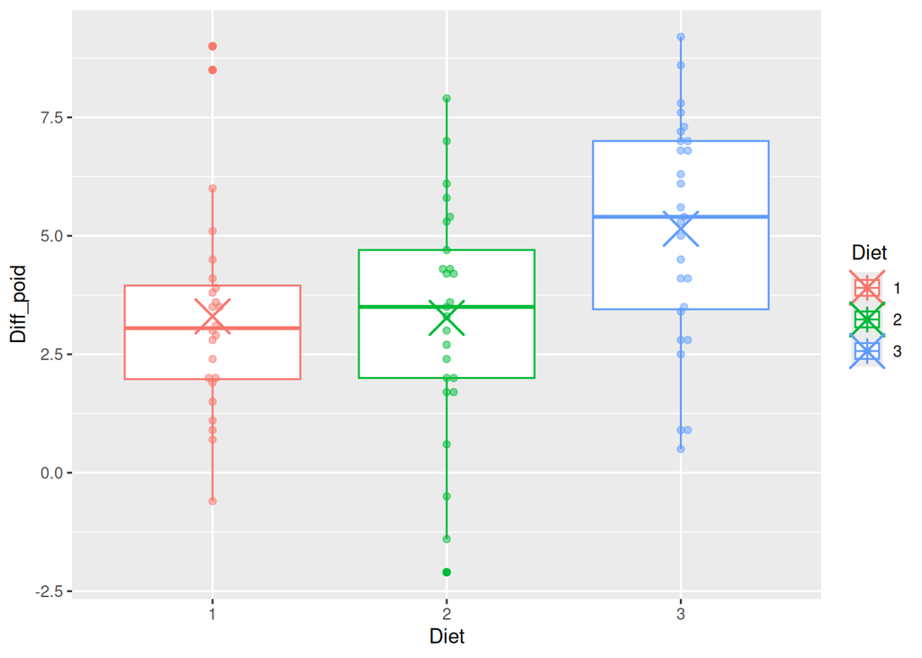

```r
library(ggbeeswarm)
ggplot(diet, aes( x = Diet, y = Diff_poid, color = Diet)) +
geom_boxplot() +
geom_beeswarm(alpha = 0.5) +
stat_summary(size = 2, shape = 4, fun = mean)
```

## 2.6 ANOVA sans intercept sur R

```r
mod_ssinter <- lm(Diff_poid~ Diet - 1, data = diet)
summary(mod_ssinter)
```

```
Call:
lm(formula = Diff_poid ~ Diet - 1, data = diet)

Residuals:
    Min      1Q  Median      3Q     Max
-5.3680 -1.4420  0.1759  1.6519  5.7000

Coefficients:
      Estimate Std. Error t value Pr(>|t|)
Diet1   3.3000     0.4840   6.818 2.26e-09 ***
Diet2   3.2680     0.4742   6.891 1.66e-09 ***
Diet3   5.1481     0.4563  11.282  < 2e-16 ***
---
Signif. codes:  0 '***' 0.001 '**' 0.01 '*' 0.05 '.' 0.1 ' ' 1

Residual standard error: 2.371 on 73 degrees of freedom
Multiple R-squared:  0.7519,    Adjusted R-squared:  0.7417
F-statistic: 73.76 on 3 and 73 DF,  p-value: < 2.2e-16
```

## 2.7 Estimation du paramètre de variance

Comme en regression linéaire multiple. Par contre, on divise par $n-p$ et non pas $n-p-1$ car on a retiré l’intercept.

$$\begin{align} S^2_{(M_p)} &= \frac{SCR(M_p)}{n-p} = \frac{||Y - X\theta||^2}{n-p}\\
& = \frac{1}{n-p} \sum_{j=1}^{p}\sum_{i=1}^{n_j}(Y_{i,j} - \overline{Y_j})^2 \end{align}$$

## 2.8 Loi de $\widehat\theta$

$\widehat\theta$ est un vecteur gaussien d’espérance $\theta$ et de matrice de covariance

$$\mathbb{V}(\widehat\theta) = \sigma^2(X^tX)^{-1}\text{ estimée par } S^2_{(M_p)}(X^tX)^{-1}$$

On montre que
$$\widehat{\theta}\sim \mathcal{N}(\theta,\sigma^2(X^tX)^{-1} )$$

En particulier, pour tout $k = 1, \cdots, p + 1$, si $c_{kk} = (X^t X )^{−1}_{k,k}$ désigne le $k$-ème élément diagonal de $(X^tX)$^{−1}, et $\widehat{\theta}_k$ désigne le $k$-ème élément du vecteur $\widehat{\theta}$, on a

$$\overline{Y}_k = \widehat{\theta}_k \sim \mathcal{N}(\theta_k,\sigma^2 c_{kk})$$

En remplaçant $\sigma^2$ par son estimateur, on a :

$$\frac{(\overline{Y}-\mu_k)}{\sqrt{S^2_{(M_p)}c_{kk}}} \sim \mathcal{T}(n-p)$$

## 2.9 Forme explicite de $c_{kk}$

$$\left({X^{(1)}}^tX^{(1)}\right)^{-1} = \begin{bmatrix}\frac{1}{n_1} & 0 & 0 \\0 & \frac{1}{n_2} & 0\\ 0 & 0 & \frac{1}{n_3} \end{bmatrix}$$

$$c_{kk} = \frac{1}{n_k}$$
$$\overline{Y}_k = \widehat{\theta}_k \sim \mathcal{N}\left(\theta_k,\frac{\sigma^2}{n_k}\right)$$

En remplaçant $\sigma^2$ par son estimateur, on a :

$$\frac{(\overline{Y}-\mu_k)}{\sqrt{\frac{S^2_{(M_p)}}{n_k}}} \sim \mathcal{T}(n-p)$$

## 2.10 Intervalle de confiance du modèle sans intercept

**TipIntervalle de confiance pour l’ANOVA à 1 facteur sans intercept**

$$IC_{1-\delta}(\mu_k) = \left[\overline{y}_i - t_{1-\frac{\delta}{2}}\frac{s_{M_p}}{\sqrt{n_i}};\;\overline{y}_i + t_{1-\frac{\delta}{2}}\frac{s_{M_p}}{\sqrt{n_i}} \right]$$

où $t_{1-\frac{\delta}{2}}$ est le quantile $1-\frac{\delta}{2}$ de la loi $\mathcal{T}(n-p)$

```r
confint(mod_ssinter, level = 0.95)
```

```
         2.5 %   97.5 %
Diet1 2.335407 4.264593
Diet2 2.322895 4.213105
Diet3 4.238721 6.057575
```

## 2.11 Test de Student

**TipHypothèses**

$$H_0 : \mu_k = 0 \text{ contre } H_1 : \mu_k \neq 0$$

**CautionRemarques**

Il s’agit d’un test de conformité de moyenne, on regarde si la moyenne de chaque groupe est significativement différente de 0.

**TipStatistique de test**

Sous $H_0$, on a
$$T_n = \frac{(\overline{Y}-\mu_k)}{\sqrt{\frac{S^2_{(M_p)}}{n_k}}}\sim\mathcal{T}(n-p)$$

**CautionRemarques**

À part l’estimation de $\sigma^2$ c’est comme le test de Student vu en test paramétrique.

## 2.12 ANOVA sans intercept sur R

```r
mod_ssinter <- lm(Diff_poid~ Diet - 1, data = diet)
summary(mod_ssinter)
```

```
Call:
lm(formula = Diff_poid ~ Diet - 1, data = diet)

Residuals:
    Min      1Q  Median      3Q     Max
-5.3680 -1.4420  0.1759  1.6519  5.7000

Coefficients:
      Estimate Std. Error t value Pr(>|t|)
Diet1   3.3000     0.4840   6.818 2.26e-09 ***
Diet2   3.2680     0.4742   6.891 1.66e-09 ***
Diet3   5.1481     0.4563  11.282  < 2e-16 ***
---
Signif. codes:  0 '***' 0.001 '**' 0.01 '*' 0.05 '.' 0.1 ' ' 1

Residual standard error: 2.371 on 73 degrees of freedom
Multiple R-squared:  0.7519,    Adjusted R-squared:  0.7417
F-statistic: 73.76 on 3 and 73 DF,  p-value: < 2.2e-16
```

## 2.13 Test de Fisher

**TipHypothèses**

$H_0$: On est dans le modèle $M_0 : Y_i = E_i$

contre

$H_1$: On est dans le modèle $M_p : Y_{i,j} = \mu_j + E_i$

**TipAutre formulation**

$H_0$: On est dans le modèle $M_0 : \mu_1 = \mu_2 = \dots = \mu_p = 0$

contre

$H_1$: On est dans le modèle $M_p : \exists j \in \{1,\dots,j\}, \mu_j \neq 0$

```r
m0 <- lm(Diff_poid~0, data = diet)
anova(m0, mod_ssinter)
```

```
Analysis of Variance Table

Model 1: Diff_poid ~ 0
Model 2: Diff_poid ~ Diet - 1
  Res.Df    RSS Df Sum of Sq      F    Pr(>F)
1     76 1654.3
2     73  410.4  3      1244 73.755 < 2.2e-16 ***
---
Signif. codes:  0 '***' 0.001 '**' 0.01 '*' 0.05 '.' 0.1 ' ' 1
```

## 2.14 Remarques

**CautionRemarques**

$\Longrightarrow$ Il n’y a pas de comparaison des moyennes entre elles !

# 3 ANOVA avec groupe de référence

## 3.1 Notation non matricielle dans l’exemple

**NoteDéfinition : ANOVA à un facteur avec groupe de référence**

$$Y_i = \beta + \alpha_ 2X_{i,2}^{(1)}+ \alpha_ 3X_{i,3}^{(1)} + E_i$$

Si l’individu $i$ a fait le **régime 1, qui est le régime de référence**, alors $X_{i,2}^{(1)} = 0$ et $X_{i,3}^{(1)} = 0$ donc

$$Y_i = \beta + E_i$$

Si l’individu $i$ a fait le **régime 2**, alors $X_{i,2}^{(1)} = 1$ et $X_{i,3}^{(1)} = 0$ donc

$$Y_i = \beta +\alpha_2+ E_i$$

Si l’individu $i$ a fait le **régime 3**, alors $X_{i,2}^{(1)} = 0$ et $X_{i,3}^{(1)} = 1$ donc

$$Y_i = \beta +\alpha_3+ E_i$$

**La prise de poid de l’individu $i$ est modélisée par une valeur de référence plus une valeur dépendant de son régime et une erreur**

## 3.2 Notation matricielle dans l’exemple

**NoteDéfinition : ANOVA à un facteur avec groupe de référence**

$$Y = X^{(1)}\theta + E$$
où

- $Y = [Y_1,\dots,Y_n]^t$ les v.a. liées à la prise de poids de l’individu $\{1, \dots,n\}$.
- $X^{(1)}$ est la matrice encodée du facteur “type de régime” sans la première colonne.

$$X^{(1)} = \left[\begin{array}{ccc}\text{intercept} & \text{Régime 2} & \text{Régime 3} \\ 1 & 0 & 0 \\ 1 & 1 & 0 \\1 & 0 & 0 \\1 & 0 & 1 \\1 & 1 & 0 \\1 & 0 & 1 \\ \vdots &\vdots &\vdots \end{array}\right]$$

- $\theta = [\beta,\alpha_2,\alpha_3]^t$.
- $E \sim \mathcal{N}(0,\sigma^2 I_n)$.

**La prise de poid de l’individu $i$ est modélisée par une valeur de référence plus une valeur dépendant de son régime et une erreur**

## 3.3 Interprétation des paramètres

**Pour le régime 1 :**
$$Y_{i,1}\sim\mathcal{N}(\beta,\sigma^2)$$

donc $\beta = \mu_1$, il s’agit de la moyenne du groupe de référence.

**Pour le régime 2 :**
$$Y_{i,1}\sim\mathcal{N}(\beta + \alpha_2,\sigma^2)$$

$\mu_2 = \mu_1+ \alpha_2$, donc $\alpha_2 = \mu_2 - \mu_1$ $\Longrightarrow\alpha_2$ représente l’écart en moyenne entre le régime 2 et le régime de référence 1.

**Pour le régime 3 :**
$$Y_{i,1}\sim\mathcal{N}(\beta + \alpha_3,\sigma^2)$$

$\mu_3 = \mu_1+ \alpha_3$, donc $\alpha_3 = \mu_3 - \mu_1$ $\Longrightarrow\alpha_3$ représente l’écart en moyenne entre le régime 3 et le régime de référence 1.

## 3.4 Notation matricielle

**NoteDéfinition : ANOVA à un facteur avec groupe de référence**

$$Y = X^{(1)}\theta + E$$
où

- $Y = [Y_1,\dots,Y_n]^t$ les v.a. à expliquer.
- $X^{(1)}$ est la matrice encodée du facteur sans le groupe 1.
- $\theta = [\beta,\alpha_2,\dots,\alpha_p]^t$.
- $E \sim \mathcal{N}(0,\sigma^2 I_n)$.

**CautionRemarques**

En posant comme contrainte $\alpha_1=0$ et $\mu_j = \beta + \alpha_j$, on retombe bien sur le modèle

$$Y_{i,j} = \beta + \alpha_j + E_i =\mu_j + E_i, \quad E_i\overset{i.i.d.}{\sim}\mathcal{N}(0,\sigma^2)$$

$$\iff Y_{i,j}\sim\mathcal{N}(\mu_j,\sigma^2)$$

## 3.5 Estimateur

En refaisant les calculs avec $\widehat{\theta} = \left({X^{(1)}}^tX^{(1)}\right)^{-1}{X^{(1)}}^tY$ on trouve

**TipEstimateur**

$$\widehat{\beta} = \overline{Y_1}$$

$$\widehat{\alpha}_j = \overline{Y_j} - \overline{Y_1} = \left(\frac{1}{n_j}\sum_{i=1}^{n_j}Y_{i,j} \right) - \overline{Y_1}$$

## 3.6 Lecture sur R

**CautionRemarques**

**Par défaut c’est le premier facteur qui est le groupe de référence dans R**

```r
mod_c1 <- lm(Diff_poid~Diet, diet)
summary(mod_c1)
```

```
Call:
lm(formula = Diff_poid ~ Diet, data = diet)

Residuals:
    Min      1Q  Median      3Q     Max
-5.3680 -1.4420  0.1759  1.6519  5.7000

Coefficients:
            Estimate Std. Error t value Pr(>|t|)
(Intercept)   3.3000     0.4840   6.818 2.26e-09 ***
Diet2        -0.0320     0.6776  -0.047  0.96246
Diet3         1.8481     0.6652   2.778  0.00694 **
---
Signif. codes:  0 '***' 0.001 '**' 0.01 '*' 0.05 '.' 0.1 ' ' 1

Residual standard error: 2.371 on 73 degrees of freedom
Multiple R-squared:  0.1285,    Adjusted R-squared:  0.1047
F-statistic: 5.383 on 2 and 73 DF,  p-value: 0.006596
```

## 3.7 Loi de l’estimateur

**TipLoi de l’estimateur**

$\widehat{\beta} \sim \mathcal{N}\left(\beta,\frac{\sigma^2}{n_1}\right)$

Pour $j\neq 1$, on a $\widehat{\alpha}_j \sim \mathcal{N}\left(\alpha_i,\frac{\sigma^2}{n_i}+\frac{\sigma^2}{n_1}\right)$

**TipLoi de l’estimateur**

Pour $j\neq 1$:
$$T = \frac{\widehat{\alpha_j}}{\sqrt{S^2(M_p)\left(\frac{1}{n_1} + \frac{1}{n_j}\right)}}\sim\mathcal{T}(n-p)$$
où
$$S^2_{(M_p)} = \frac{SCR(M_p)}{n-p}$$

**CautionRemarques**

On retrouve la statistique de test de Student de comparaison de deux moyennes.

## 3.8 Interprétation du test de Student dans l’exemple

1. Test de $H_0 : \beta = 0$ contre $H_1 : \beta \neq 0$

$\iff H_0 :\mu_1 = 0$ contre $H_1 : \mu_1 \neq 0$

Est-ce que le groupe de référence a une moyenne significativement différente de 0 ?

2. Test de $H_0 : \alpha_2 = 0$ contre $H_1 : \alpha_2 \neq 0$

$\iff H_0 :\mu_2 - \mu_1 = 0$ contre $H_1 : \mu_2- \mu_1 \neq 0$

Est-ce que le groupe 2 a une moyenne significativement différente du groupe de référence ?

3. Test de $H_0 : \alpha_3 = 0$ contre $H_1 : \alpha_3 \neq 0$

$\iff H_0 :\mu_3 - \mu_1 = 0$ contre $H_1 : \mu_3 - \mu_1 \neq 0$

Est-ce que le groupe 3 a une moyenne significativement différente du groupe de référence ?

## 3.9 Test sur R

**CautionRemarques**

**Par défaut c’est le premier facteur qui est le groupe de référence dans R**

```r
mod_c1 <- lm(Diff_poid~Diet, diet)
summary(mod_c1)
```

```
Call:
lm(formula = Diff_poid ~ Diet, data = diet)

Residuals:
    Min      1Q  Median      3Q     Max
-5.3680 -1.4420  0.1759  1.6519  5.7000

Coefficients:
            Estimate Std. Error t value Pr(>|t|)
(Intercept)   3.3000     0.4840   6.818 2.26e-09 ***
Diet2        -0.0320     0.6776  -0.047  0.96246
Diet3         1.8481     0.6652   2.778  0.00694 **
---
Signif. codes:  0 '***' 0.001 '**' 0.01 '*' 0.05 '.' 0.1 ' ' 1

Residual standard error: 2.371 on 73 degrees of freedom
Multiple R-squared:  0.1285,    Adjusted R-squared:  0.1047
F-statistic: 5.383 on 2 and 73 DF,  p-value: 0.006596
```

**NoteInterprétation**

- Le Régime 1 fait gagner en moyenne de 3.3kg, ce qui est significativement différent de 0.
- L’écart entre le Régime 1 et 2 vaut en moyenne -0.03kg et n’est pas significativement différent de 0 : les régimes 1 et 2 ont des espérance semblable.
- L’écart entre le Régime 1 et 3 vaut en moyenne 1.8481kg, cet écart est significativement différent de 0.

**Conclusion** : Comparé au régime 1 , le régime 2 n’est pas significativement différent, et le régime 3 fait gagner plus de poids.